# Assignment

…

6/2/2022

## Viewing dataset

```
## # A tibble: 6 × 82
##   Date                m1_en_mg m2_en_mg m3_en_mg  ...5 m1_usd m2_usd m3_usd
##   <dttm>                 <dbl>    <dbl>    <dbl> <dbl>  <dbl>  <dbl>  <dbl>
## 1 1958-09-01 00:00:00     90.0     122.       NA    NA   18.0   24.4     NA
## 2 1959-09-01 00:00:00     85.7     119.       NA    NA   17.1   23.9     NA
## 3 1960-09-01 00:00:00     93.4     130.       NA    NA   18.7   25.9     NA
## 4 1961-09-01 00:00:00     93.5     132.       NA    NA   18.7   26.4     NA
## 5 1962-09-01 00:00:00     90.6     132.       NA    NA   18.1   26.3     NA
## 6 1963-09-01 00:00:00     97.6     138.       NA    NA   19.5   27.5     NA
## # … with 74 more variables: ...9 <dbl>, tdc_brh <dbl>, ...11 <dbl>,
## #   base_mon_mg_usd <dbl>, base_mon <dbl>, monnaie_circ_mg <dbl>, ...15 <dbl>,
## #   credit_sec_pub_mon_mg <dbl>, multiplicateur_m3_b <dbl>,
## #   multiplicateur_m2_b <dbl>, multiplicateur_m1_b <dbl>, ...20 <dbl>,
## #   reserves_nettes_de_change_brh_mg <dbl>,
## #   reserves_nettes_de_change_sb_mg <dbl>, ...23 <dbl>,
## #   infl_glisse_annuel_en_poucent <dbl>, ...25 <dbl>, …
```

There are lots of variables so we can select 3 variables as required by question.

Firstly we check the time series of the data and it’s relation with m1_usd using plot command.

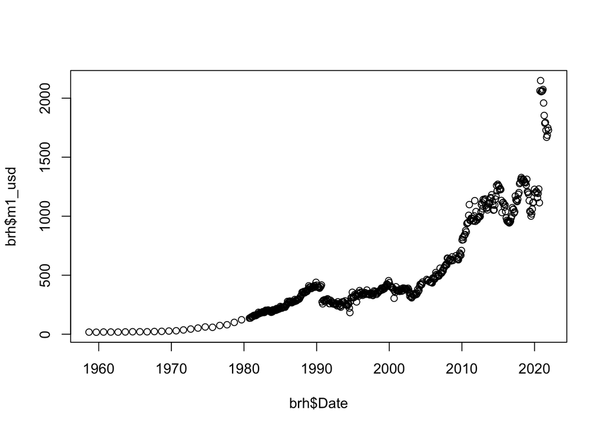

We analyse that relation between these variables is non–linear. We can do the same procedure for other variable as well.

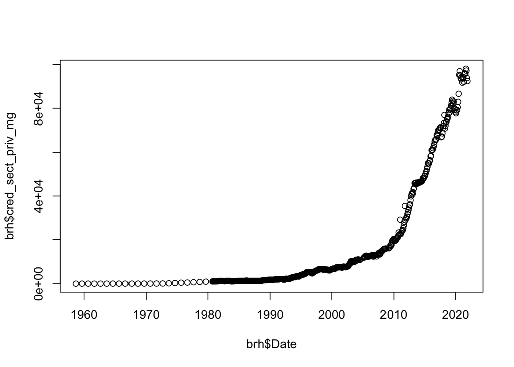

## stationary Test

H0: Variables have Unit Root  
Ha: Variable is stationary

We assume significance level of 0.05.

```
## Augmented Dickey-Fuller Test
## alternative: stationary
##
## Type 1: no drift no trend
##      lag  ADF p.value
## [1,]   0 7.49    0.99
## [2,]   1 8.09    0.99
## [3,]   2 7.79    0.99
## [4,]   3 6.61    0.99
## [5,]   4 7.30    0.99
## [6,]   5 7.53    0.99
## [7,]   6 8.00    0.99
## Type 2: with drift no trend
##      lag  ADF p.value
## [1,]   0 6.34    0.99
## [2,]   1 6.94    0.99
## [3,]   2 6.75    0.99
## [4,]   3 5.75    0.99
## [5,]   4 6.43    0.99
## [6,]   5 6.70    0.99
## [7,]   6 7.21    0.99
## Type 3: with drift and trend
##      lag  ADF p.value
## [1,]   0 3.60    0.99
## [2,]   1 4.09    0.99
## [3,]   2 4.08    0.99
## [4,]   3 3.46    0.99
## [5,]   4 4.06    0.99
## [6,]   5 4.37    0.99
## [7,]   6 4.87    0.99
## ----
## Note: in fact, p.value = 0.01 means p.value <= 0.01
```

## Verifying sense de la causalite

Granger causalite test is used to test the causal relationship between two time series. Just like to stationary test, we define our two hypothesis as

H0: Time series data US dollar `m1_usd` is not causally related to variable `cred_sect_priv_mg`. HA: Time series data US dollar `m1_usd` is causally related to variable `cred_sect_priv_mg`

It will help us to analyze of the first time series data predicts the future of the second time series data.

```
## Granger causality test
##
## Model 1: m1_usd ~ Lags(m1_usd, 1:3) + Lags(cred_sect_priv_mg, 1:3)
## Model 2: m1_usd ~ Lags(m1_usd, 1:3)
##   Res.Df Df      F   Pr(>F)
## 1    496
## 2    499 -3 23.824 2.03e-14 ***
## ---
## Signif. codes:  0 '***' 0.001 '**' 0.01 '*' 0.05 '.' 0.1 ' ' 1
```

The result from the granger causalite test shows two models.

Model 2 uses only the value of in previous 3 years for price in usd.

F-test value comes out to be 23.82. p-value is less than 0.05 which is our significance level at 95% confidence interval. Hence we reject our null hypothesis and accept the alternative hypothesis. Hence we conclude that knowing the value of variable `cred_sect_priv_mg` is predictive of the variable `m1_usd`.

We can do the reverse causation test to check if the reverse is true for our hypothesis. It means we can check if the usd is predictive of `cred_sect_priv_mg`. For that purpose we use following command.

[output not shown]

So in short both values can predict each other.

## Regression test

Now we will do the linear test using one variable as independent and other as dependent. Since it is required to use same variables as casuality test so we use dataset `brh` here as well. Note that there is no control variable for the dependent variable hence the result should be straight forward to analyze and the test should be only linear regression instead of multiple linear regression. We can define our hypothesis in this test

H0: Variable `m1_`usd`is not linear related to variable`cred_sect_priv_mg`HA: Variable`m1_usd`has a linear relation to variable`cred_sect_priv_mg`

Our significance level is again 5%.

```
##
## Call:
## lm(formula = m1_usd ~ cred_sect_priv_mg, data = brh)
##
## Residuals:
##     Min      1Q  Median      3Q     Max
## -576.94  -79.84  -12.32   87.63  504.92
##
## Coefficients:
##                    Estimate Std. Error t value Pr(>|t|)
## (Intercept)       2.717e+02  8.605e+00   31.57   <2e-16 ***
## cred_sect_priv_mg 1.464e-02  2.550e-04   57.40   <2e-16 ***
## ---
## Signif. codes:  0 '***' 0.001 '**' 0.01 '*' 0.05 '.' 0.1 ' ' 1
##
## Residual standard error: 155.4 on 504 degrees of freedom
## Multiple R-squared:  0.8673, Adjusted R-squared:  0.8671
## F-statistic:  3294 on 1 and 504 DF,  p-value: < 2.2e-16
```

[output not shown]